# 2021-12-08 Img collages

# Background

It would be great to see a few example images from each label3 class to get a feeling of class diversity. The idea is to make an image collage for each class comprised of the four largest and smallest images in each class.

# Access image file info

I have a list of the image info and the taxonomic labels. list I want to add the file size of each image to this list. To retrieve file size info, I will make a list of the files in the data folder.

Note, there are some duplicates (from an earlier augmentation effort) in the folder. I will remove those for this analysis.

- index_all: all images
- index: unique images (no duplicates)

```r
  # read index file
  index_all <- read.csv("/scratch/data/index.csv", header = TRUE)

  # retrieve file info
  objs <- file.info(list.files("/scratch/data/images/", full.names = TRUE))
  knitr::kable(head(objs))
```

|  | size | isdir | mode | mtime | ctime | atime | uid | gid | uname | grname |
| --- | --- | --- | --- | --- | --- | --- | --- | --- | --- | --- |
| /scratch/data/images//Pia1.2016-08-02.1631+N38_hc._fx.tif | 54202 | FALSE | 755 | 2021-12-08 15:30:47 | 2021-12-08 15:30:47 | 2021-12-09 15:42:31 | 706001132 | 706000513 | robert.blackwell | domain users |
| /scratch/data/images//Pia1.2016-08-02.1631+N38_hc._fxy.tif | 54202 | FALSE | 755 | 2021-12-08 15:30:47 | 2021-12-08 15:30:47 | 2021-12-09 15:42:32 | 706001132 | 706000513 | robert.blackwell | domain users |
| /scratch/data/images//Pia1.2016-08-02.1631+N38_hc._fy.tif | 54202 | FALSE | 755 | 2021-12-08 15:30:47 | 2021-12-08 15:30:47 | 2021-12-09 15:42:32 | 706001132 | 706000513 | robert.blackwell | domain users |
| /scratch/data/images//Pia1.2016-08-02.1631+N38_hc.tif | 54202 | FALSE | 755 | 2021-12-08 15:30:47 | 2021-12-08 15:30:47 | 2021-12-09 15:42:32 | 706001132 | 706000513 | robert.blackwell | domain users |
| /scratch/data/images//Pia1.2016-08-02.1631+N67_hc._fx.tif | 56842 | FALSE | 755 | 2021-12-08 15:30:47 | 2021-12-08 15:30:47 | 2021-12-09 15:42:33 | 706001132 | 706000513 | robert.blackwell | domain users |
| /scratch/data/images//Pia1.2016-08-02.1631+N67_hc._fxy.tif | 56842 | FALSE | 755 | 2021-12-08 15:30:47 | 2021-12-08 15:30:47 | 2021-12-09 16:17:17 | 706001132 | 706000513 | robert.blackwell | domain users |

```r
  # clean file names
  objs$filename_long  <- rownames(objs)
  objs$filename       <- sub("/scratch/data/images//", "", objs$filename_long)

  # add image size to index file
  index_all$size <- objs$size[match(index_all$filename, objs$filename)]
```

So, I noticed that some images have duplicate names distinguished by unique suffixes. After inspection, it appears that 574 images have been already augmented by simple rotation. I will exclude these.

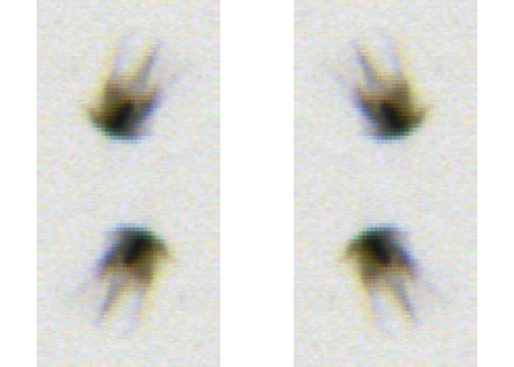

```r
  # plot image
  library(bioimagetools)
  # plot example of duplicate images
  par(pty = "s", mfrow = c(2,2), mar = c(0,0,0,0))
   for(i in grep("Pia1\\.2017\\-10\\-03\\.1726\\+N00359755", index_all$filename)) {
    IMG_NAME <- paste("/scratch/data/images/", index_all$filename[i], sep="")
    img      <- readTIF(IMG_NAME)

    img(img, z = 1, col = "rgb")
   }
```

```r
  par(pty = "m")

  # number of rotated images
  table(grepl("fxy\\.tif", index_all$filename))
```

```
##
## FALSE  TRUE
## 58217   574
```

```r
  table(grepl("fx\\.tif",  index_all$filename))
```

```
##
## FALSE  TRUE
## 58217   574
```

```r
  table(grepl("fy\\.tif",  index_all$filename))
```

```
##
## FALSE  TRUE
## 58217   574
```

```r
  # exclude duplicate images
  index <- index_all[!(grepl("fxy\\.tif", index_all$filename)|
                       grepl("fx\\.tif", index_all$filename) |
                       grepl("fy\\.tif", index_all$filename) ), ]
```

Extract largest and smallest 5 images of each group.

I then make a collage for each type and save these. To each collage, I add a scalebar, which I made in Adobe Illustrator. I also add the name of the label3 class and the number of images within the class.

Note, there are 39 groups in label3.

I commented out the image saving command here. Please enable if you want to regenerate the images.

```r
  library(dplyr)
```

```r
  # sort all images according to size, group by label3 and only take top 5 each.
  largest_5 <- index %>%
    arrange(desc(size)) %>%
    group_by(label3) %>% slice(1:5)

  smallest_5 <- index %>%
    arrange(size) %>%
    group_by(label3) %>% slice(1:5)

  # extract images
  library(magick)
  # read scale bar image
  img_scalebar <- image_read("/home/sari.giering/git/plankton-dsg-challenge/data/collages/scalebar_100px.tif")[1]

  for(TYPE in levels(index$label3)) {

    # number of objects for TYPE
    n <- length(index$label3[index$label3 %in% TYPE])

    # load 4 largest and smallest images
    for(i in 1:4) {
      IMG_NAME <- paste("/scratch/data/images/", largest_5[largest_5$label3 %in% TYPE, ]$filename[i], sep="")
      img      <- image_read(IMG_NAME)
      assign(paste("img_L", i, sep="_"), img)

      IMG_NAME <- paste("/scratch/data/images/", smallest_5[smallest_5$label3 %in% TYPE, ]$filename[i], sep="")
      img      <- image_read(IMG_NAME)
      assign(paste("img_S", i, sep="_"), img)
    }

    # collate images
    col_L   <- image_append(c(img_L_1, img_L_2, img_L_3, img_L_4))
    col_S   <- image_append(c(img_S_1, img_S_2, img_S_3, img_S_4, img_scalebar))
    col_all <- image_append(c(col_L, col_S), stack = TRUE)

    # add annotation
    ANNOT <- paste(TYPE, " (n = ", n, ")", sep="")
    col_annotated <- image_annotate(col_all, ANNOT, size = 20, gravity = "northwest")

    # make filename
    FILENAME <- paste("/home/sari.giering/git/plankton-dsg-challenge/data/collages/collage_", TYPE,  "_n", n, ".png", sep = "")

    # ---- SAVE IMAGES ----
    #image_write(col_annotated, path = FILENAME, format = "png")
  }
```

# Class imbalances

I use this opportunity to illustrate the class imbalances. To add a bit more information to the plot, I also include information on the median file size, which is a proxy for object size.

The resulting plot nicely illustrates the variability in class size and class diversity of label3 images. Error bars show Q1 and Q3 (25% and 75% of data).

I commented out the table saving command here. Please enable if you want to save the table.

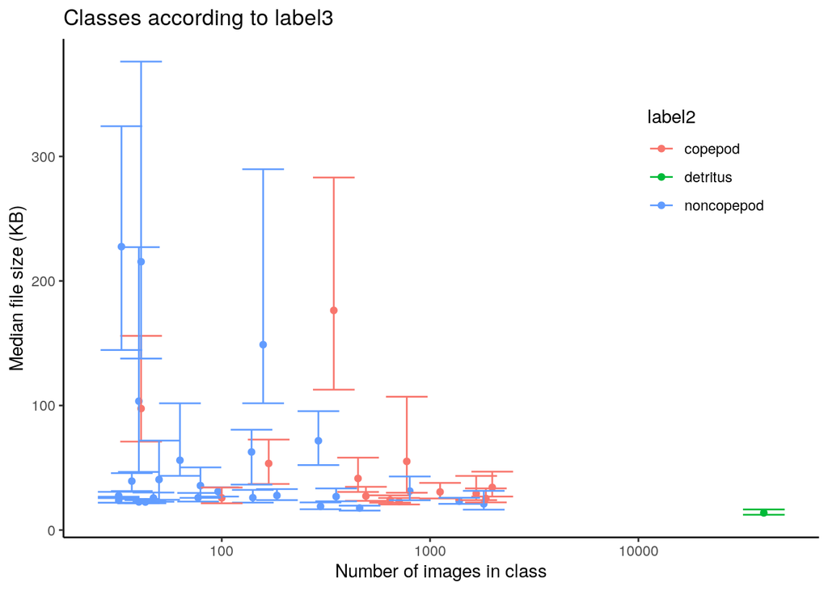

```r
  classes <- aggregate(index$filename, by = list("label1" = index$label1,
                                      "label2" = index$label2,
                                      "label3" = index$label3), length)

  classes$median_size <- aggregate(index$size, by = list("label1" = index$label1,
                                      "label2" = index$label2,
                                      "label3" = index$label3), median)$x

  classes$size_q1 <- aggregate(index$size, by = list("label1" = index$label1,
                                      "label2" = index$label2,
                                      "label3" = index$label3), quantile, probs = 0.25)$x

  classes$size_q3 <- aggregate(index$size, by = list("label1" = index$label1,
                                      "label2" = index$label2,
                                      "label3" = index$label3), quantile, probs = 0.75)$x

  library(ggplot2)
  ggplot(classes, aes(x = x, y = median_size/1000, color = label2)) +
      geom_point() +
      geom_errorbar(aes(ymin = size_q1/1000, ymax = size_q3/1000), width = 0.2) +
      scale_x_continuous(trans = 'log10') +
      theme_classic() + theme(legend.position=c(0.85, 0.75)) +
      ylab("Median file size (KB)") +
      xlab("Number of images in class") + ggtitle("Classes according to label3")
```

```r
  knitr::kable(classes[rev(order(classes$x)),])
```

|  | label1 | label2 | label3 | x | median_size | size_q1 | size_q3 |
| --- | --- | --- | --- | --- | --- | --- | --- |
| 25 | detritus | detritus | detritus | 40000 | 13786 | 12298.0 | 16522.0 |
| 15 | zooplankton | copepod | copepod_calanoida_para-pseudocalanus-spp | 1988 | 34234 | 26904.0 | 46909.5 |
| 23 | zooplankton | copepod | copepod_unknown | 1853 | 25366 | 22234.0 | 33466.0 |
| 37 | zooplankton | noncopepod | radiolaria | 1810 | 21034 | 16378.0 | 31498.0 |
| 10 | zooplankton | copepod | copepod_calanoida | 1665 | 29290 | 24044.0 | 43450.0 |
| 22 | zooplankton | noncopepod | copepod_nauplii | 1380 | 23098 | 21034.0 | 25930.0 |
| 18 | zooplankton | copepod | copepod_cyclopoida_corycaeus-spp | 1117 | 30634 | 25370.0 | 37868.0 |
| 26 | zooplankton | noncopepod | echniodermata-larvae | 799 | 31306 | 23914.0 | 43018.0 |
| 14 | zooplankton | copepod | copepod_calanoida_centropages-spp | 773 | 55130 | 29962.0 | 107050.0 |
| 20 | zooplankton | copepod | copepod_cyclopoida_oncaea-spp | 710 | 22923 | 20554.0 | 25750.0 |
| 21 | zooplankton | copepod | copepod_harpacticoida | 643 | 24118 | 22006.0 | 27863.0 |
| 19 | zooplankton | copepod | copepod_cyclopoida_oithona-spp | 492 | 27274 | 23459.5 | 34714.0 |
| 34 | zooplankton | noncopepod | nt-phyto_ceratium-spp | 459 | 17674 | 15634.0 | 19594.0 |
| 11 | zooplankton | copepod | copepod_calanoida_acartia-spp | 451 | 41446 | 30610.0 | 58151.0 |
| 33 | zooplankton | noncopepod | nt-bubbles | 354 | 26890 | 23098.0 | 33430.0 |
| 12 | zooplankton | copepod | copepod_calanoida_calanus-spp | 345 | 176362 | 112714.0 | 283066.0 |
| 32 | zooplankton | noncopepod | nt_phyto_chains | 298 | 19042 | 16714.0 | 22186.0 |
| 39 | zooplankton | noncopepod | tunicata_doliolida | 291 | 71706 | 52186.0 | 95444.0 |
| 35 | zooplankton | noncopepod | nt-phyto_rhizosolenia-spp | 184 | 27754 | 24035.5 | 32890.0 |
| 16 | zooplankton | copepod | copepod_calanoida_temora-spp | 168 | 53464 | 37006.0 | 72646.0 |
| 5 | zooplankton | noncopepod | chaetognatha | 158 | 148858 | 101794.0 | 289714.0 |
| 1 | zooplankton | noncopepod | annelida_polychaeta | 141 | 25978 | 22054.0 | 32230.0 |
| 28 | zooplankton | noncopepod | euphausiid_nauplii | 139 | 62698 | 36490.0 | 80547.0 |
| 17 | zooplankton | copepod | copepod_cyclopoida | 100 | 25810 | 21514.0 | 34162.0 |
| 4 | zooplankton | noncopepod | byrozoa-larvae | 96 | 30922 | 26890.0 | 34280.5 |
| 2 | zooplankton | noncopepod | appendicularia | 79 | 35674 | 25834.0 | 50320.0 |
| 6 | zooplankton | noncopepod | cirripedia_barnacle-nauplii | 77 | 25978 | 22874.0 | 29770.0 |
| 9 | zooplankton | noncopepod | cnidaria | 63 | 56026 | 43522.0 | 101770.0 |
| 29 | zooplankton | noncopepod | fish-eggs | 50 | 40570 | 24298.0 | 71830.0 |
| 36 | zooplankton | noncopepod | ostracoda | 47 | 25750 | 22714.0 | 30144.0 |
| 3 | zooplankton | noncopepod | bivalvia-larvae | 43 | 22486 | 21526.0 | 23968.0 |
| 27 | zooplankton | noncopepod | euphausiid | 41 | 215466 | 137704.0 | 376138.0 |
| 13 | zooplankton | copepod | copepod_calanoida_candacia-spp | 41 | 97546 | 71050.0 | 155914.0 |
| 30 | zooplankton | noncopepod | gastropoda-larva | 40 | 22570 | 21527.5 | 24971.5 |
| 24 | zooplankton | noncopepod | decapoda-larvae_brachyura | 40 | 103498 | 46642.0 | 227146.0 |
| 7 | zooplankton | noncopepod | cladocera | 37 | 39286 | 31306.0 | 45706.0 |
| 31 | zooplankton | noncopepod | mysideacea | 33 | 227530 | 144538.0 | 324250.0 |
| 38 | zooplankton | noncopepod | tintinnida | 32 | 23811 | 21958.0 | 26794.0 |
| 8 | zooplankton | noncopepod | cladocera_evadne-spp | 32 | 27544 | 25651.0 | 30685.0 |

```r
  # ---- SAVE TABLE ----
  #write.csv(classes[rev(order(classes$x)),], "out.csv", row.names = FALSE)
```